# CustomersGoodsClassification

[return](http://www.malikhouni.com/)

0 - Classification pour "Place de marché"

### Classification de produits par images et mots

## Consignes:

Vous **analyserez le jeu de données** en réalisant **un prétraitement** des images et des descriptions des produits, **une réduction de dimension**, puis un **clustering**. Les résultats du clustering seront présentés sous la forme d’**une représentation en deux dimensions** à déterminer, qui ’illustrera le fait que les caractéristiques extraites permettent de regrouper des produits de même catégorie.

La **représentation graphique** vous aidera à convaincre Linda que cette approche de modélisation permettra bien de regrouper des produits de même catégorie.

# 1 - Librairies et fichiers de données

```python
import numpy as np
import pandas as pd
import matplotlib.pyplot as plt
import seaborn as sns

#For ImageClassification
from skimage.io import imread
from IPython.display import Image
import os
import cv2
from sklearn.cluster import MiniBatchKMeans
from xgboost import XGBRFClassifier
from sklearn.metrics import accuracy_score

#for WordClassification
import re
import nltk
from nltk.tokenize import word_tokenize as wt
from nltk.corpus import stopwords
from nltk.stem.porter import PorterStemmer
from sklearn.feature_extraction.text import CountVectorizer
from sklearn.naive_bayes import GaussianNB
from sklearn.metrics import confusion_matrix, classification_report, accuracy_score

import warnings
warnings.simplefilter(action='ignore', category=FutureWarning)
```

```python
data = pd.read_csv('flipkart_com-ecommerce_sample_1050.csv')
print(data.shape)
display(data.head(2))
```

```
(1050, 15)
```

|  | uniq_id | crawl_timestamp | product_url | product_name | product_category_tree | pid | retail_price | discounted_price | image | is_FK_Advantage_product | description | product_rating | overall_rating | brand | product_specifications |
| --- | --- | --- | --- | --- | --- | --- | --- | --- | --- | --- | --- | --- | --- | --- | --- |
| 0 | 55b85ea15a1536d46b7190ad6fff8ce7 | 2016-04-30 03:22:56 +0000 | http://www.flipkart.com/elegance-polyester-mul... | Elegance Polyester Multicolor Abstract Eyelet ... | ["Home Furnishing >> Curtains & Accessories >>... | CRNEG7BKMFFYHQ8Z | 1899.0 | 899.0 | 55b85ea15a1536d46b7190ad6fff8ce7.jpg | False | Key Features of Elegance Polyester Multicolor ... | No rating available | No rating available | Elegance | {"product_specification"=>[{"key"=>"Brand", "v... |
| 1 | 7b72c92c2f6c40268628ec5f14c6d590 | 2016-04-30 03:22:56 +0000 | http://www.flipkart.com/sathiyas-cotton-bath-t... | Sathiyas Cotton Bath Towel | ["Baby Care >> Baby Bath & Skin >> Baby Bath T... | BTWEGFZHGBXPHZUH | 600.0 | 449.0 | 7b72c92c2f6c40268628ec5f14c6d590.jpg | False | Specifications of Sathiyas Cotton Bath Towel (... | No rating available | No rating available | Sathiyas | {"product_specification"=>[{"key"=>"Machine Wa... |

```python
display(data.info())
display(data.describe(include='all'))
```

```
<class 'pandas.core.frame.DataFrame'>
RangeIndex: 1050 entries, 0 to 1049
Data columns (total 15 columns):
 #   Column                   Non-Null Count  Dtype
---  ------                   --------------  -----
 0   uniq_id                  1050 non-null   object
 1   crawl_timestamp          1050 non-null   object
 2   product_url              1050 non-null   object
 3   product_name             1050 non-null   object
 4   product_category_tree    1050 non-null   object
 5   pid                      1050 non-null   object
 6   retail_price             1049 non-null   float64
 7   discounted_price         1049 non-null   float64
 8   image                    1050 non-null   object
 9   is_FK_Advantage_product  1050 non-null   bool
 10  description              1050 non-null   object
 11  product_rating           1050 non-null   object
 12  overall_rating           1050 non-null   object
 13  brand                    712 non-null    object
 14  product_specifications   1049 non-null   object
dtypes: bool(1), float64(2), object(12)
memory usage: 116.0+ KB
```

```
None
```

|  | uniq_id | crawl_timestamp | product_url | product_name | product_category_tree | pid | retail_price | discounted_price | image | is_FK_Advantage_product | description | product_rating | overall_rating | brand | product_specifications |
| --- | --- | --- | --- | --- | --- | --- | --- | --- | --- | --- | --- | --- | --- | --- | --- |
| count | 1050 | 1050 | 1050 | 1050 | 1050 | 1050 | 1049.000000 | 1049.000000 | 1050 | 1050 | 1050 | 1050 | 1050 | 712 | 1049 |
| unique | 1050 | 149 | 1050 | 1050 | 642 | 1050 | NaN | NaN | 1050 | 2 | 1050 | 27 | 27 | 490 | 984 |
| top | aa82b75da7579007963e53b6f818281b | 2015-12-01 12:40:44 +0000 | http://www.flipkart.com/wallmantra-christ-rede... | Vitamins Solid Baby Girl's Basic Shorts | ["Home Furnishing >> Bed Linen >> Blankets, Qu... | NPYEYC9ZV2CUG9H3 | NaN | NaN | d136aa676ef52b09eab65762940957fe.jpg | False | arnavs Multi1 Bottle Opener Set Price: Rs. 250... | No rating available | No rating available | PRINT SHAPES | {"product_specification"=>[{"key"=>"Type", "va... |
| freq | 1 | 150 | 1 | 1 | 56 | 1 | NaN | NaN | 1 | 993 | 1 | 889 | 889 | 11 | 22 |
| mean | NaN | NaN | NaN | NaN | NaN | NaN | 2186.197331 | 1584.527169 | NaN | NaN | NaN | NaN | NaN | NaN | NaN |
| std | NaN | NaN | NaN | NaN | NaN | NaN | 7639.229411 | 7475.099680 | NaN | NaN | NaN | NaN | NaN | NaN | NaN |
| min | NaN | NaN | NaN | NaN | NaN | NaN | 35.000000 | 35.000000 | NaN | NaN | NaN | NaN | NaN | NaN | NaN |
| 25% | NaN | NaN | NaN | NaN | NaN | NaN | 555.000000 | 340.000000 | NaN | NaN | NaN | NaN | NaN | NaN | NaN |
| 50% | NaN | NaN | NaN | NaN | NaN | NaN | 999.000000 | 600.000000 | NaN | NaN | NaN | NaN | NaN | NaN | NaN |
| 75% | NaN | NaN | NaN | NaN | NaN | NaN | 1999.000000 | 1199.000000 | NaN | NaN | NaN | NaN | NaN | NaN | NaN |
| max | NaN | NaN | NaN | NaN | NaN | NaN | 201000.000000 | 201000.000000 | NaN | NaN | NaN | NaN | NaN | NaN | NaN |

```python
#valeur manquante
data.isna().sum()
```

```
uniq_id                      0
crawl_timestamp              0
product_url                  0
product_name                 0
product_category_tree        0
pid                          0
retail_price                 1
discounted_price             1
image                        0
is_FK_Advantage_product      0
description                  0
product_rating               0
overall_rating               0
brand                      338
product_specifications       1
dtype: int64
```

```python
data['retail_price'].fillna(data['retail_price'].mean(),inplace=True)
data['discounted_price'].fillna(data['discounted_price'].mean(),inplace=True)
data['brand'].fillna("",inplace=True)
data['product_specifications'].fillna("",inplace=True)
#valeur manquante
data.isna().sum()
```

```
uniq_id                    0
crawl_timestamp            0
product_url                0
product_name               0
product_category_tree      0
pid                        0
retail_price               0
discounted_price           0
image                      0
is_FK_Advantage_product    0
description                0
product_rating             0
overall_rating             0
brand                      0
product_specifications     0
dtype: int64
```

```python
# Exemple de la catégorie du produit 0
print(data["product_category_tree"][0])
```

```
["Home Furnishing >> Curtains & Accessories >> Curtains >> Elegance Polyester Multicolor Abstract Eyelet Do..."]
```

```
7  catégories de 1er niveau
----
Home Furnishing 150
Baby Care 150
Watches 150
Home Decor & Festive Needs 150
Kitchen & Dining 150
Beauty and Personal Care 150
Computers 150
-> en moyenne nous avons ~150 images par catégorie au niveau  de profondeur 1
```

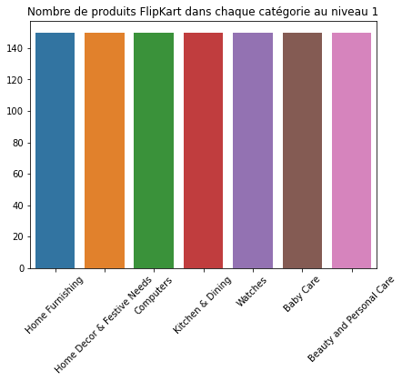

```python
# On récupère la colomne "product_category_tree"
list_categories_1=[]
list_categories_2 =[]
for txt in data["product_category_tree"] :
    list_categories_1.append(txt.split(">>")[0].split("\"")[1].strip())
    list_categories_2.append(txt.split(">>")[1].strip())


data["categories_niv1"] = pd.Series(list_categories_1)

data["categories_niv2"] = pd.Series(list_categories_2)

print(data["categories_niv1"].nunique()," catégories de 1er niveau")

print('----')
for i in data["categories_niv1"].unique():
    print(i,len(data[data["categories_niv1"]==i]))
print("-> en moyenne nous avons ~150 images par catégorie au niveau  de profondeur 1")


# Barplot
fig = plt.figure(1, figsize=(15, 5))
plt.subplot(1, 2, 1)
plt.title("Nombre de produits FlipKart dans chaque catégorie au niveau 1")

sns.barplot(data["categories_niv1"].value_counts().index, data["categories_niv1"].value_counts().values, orient="v")
plt.xticks(rotation=45)
plt.show()
```

```
63  categories au 2ième niveau de catégories
----
-> Le nombre d'image par catégorie au niveau de profondeur 2 diffère énormément
```

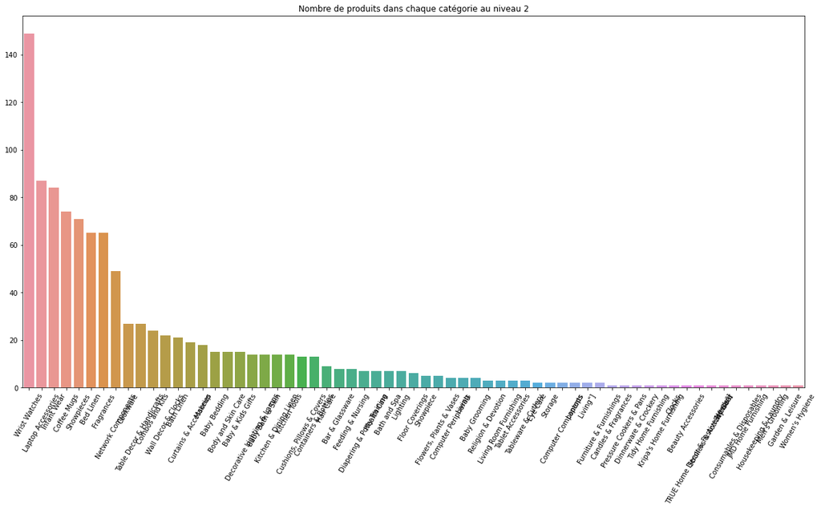

```python
print(data["categories_niv2"].nunique()," categories au 2ième niveau de catégories")
print('----')

print("-> Le nombre d'image par catégorie au niveau de profondeur 2 diffère énormément")
fig = plt.figure(1, figsize=(45, 10))
# Barplot
plt.subplot(1, 2, 1)
plt.title("Nombre de produits dans chaque catégorie au niveau 2")

sns.barplot(data["categories_niv2"].value_counts().index, data["categories_niv2"].value_counts().values, orient="v")
plt.xticks(rotation=60)
plt.show()
```

⤷ On préferera les catégorie de **niveau 1** pour le travail de classification

```python
df=data[['categories_niv1','image']].copy()
dataWCL = data[['categories_niv1','description']].copy()
```

```python
#export du ficher de data préparé.
data[['categories_niv1','image','description']].to_csv('data_Img_cat_desc.csv',index=False)
```

# 2 - Classification sur image avec algorithme ORB

## Bag-of- features model with ORB descriptors

```python
df.drop(343,axis=0,inplace=True)
```

## Extraction des keypoints de chaque images

```python
dico=[] #contients toute les images sous formes de tableau "applatit"
target_arr=[] #pour chaque image sa catégorie sous forme de nombre(baby care=0,wactches=6,...)
#Peux prendre vraiment bcp de temps(jusqu'à 18min).... mais ça marche
datadir='./Images/'
#nl,to delete:
list_image=[]

sift = cv2.xfeatures2d.SIFT_create()
orb = cv2.ORB_create()
for img in os.listdir(datadir):
    list_image.append(img)
    img_array=imread(os.path.join(datadir,img))
    #img_resized=resize(img_array,(150,150,3))
    gray_img = cv2.cvtColor(img_array, cv2.COLOR_BGR2GRAY)
    kp, des = orb.detectAndCompute(gray_img, None)
    for d in des:
        dico.append(d)
```

## Les catégories

Transformations de catégories types catégorielles en type numériques

```python
df.categories_niv1.unique()
```

```
array(['Home Furnishing', 'Baby Care', 'Watches',
       'Home Decor & Festive Needs', 'Kitchen & Dining',
       'Beauty and Personal Care', 'Computers'], dtype=object)
```

```python
df= df[df['image'].isin(list_image)].copy()

listOfCategories = ['Baby Care','Beauty and Personal Care','Computers','Home Decor & Festive Needs','Home Furnishing','Kitchen & Dining','Watches']

df.replace(['Baby Care','Beauty and Personal Care','Computers','Home Decor & Festive Needs','Home Furnishing','Kitchen & Dining','Watches'],
           [0,1,2,3,4,5,6],inplace=True)
#2 photos n'ont pas de categories, on regardes les photos et on décide de mettre la catégories 5
df.fillna(value=5,inplace=True)
df.categorie=df.categories_niv1.astype(int).copy()
```

## Clustering

Nous avons à présent un grand nombre de descripteurs par images dans un tableau. Mais il est impossible de tous les utiliser. Il faut donc regrouper en cluster.

```python
k = np.size(listOfCategories) * 10
#nl,nb image*3
batch_size = np.size(os.listdir(datadir)) * 3
kmeans = MiniBatchKMeans(n_clusters=k, batch_size=batch_size, verbose=1).fit(dico)
```

[output not shown]

[output cut: 257 more lines]

[output not shown]

## Creation des histogrammes

```python
kmeans.verbose = False

histo_list = []

for img in os.listdir(datadir):
    img_array=imread(os.path.join(datadir,img))
    gray_img = cv2.cvtColor(img_array, cv2.COLOR_BGR2GRAY)
    kp, des = orb.detectAndCompute(gray_img, None)

    histo = np.zeros(k)
    nkp = np.size(kp)

    for d in des:
        idx = kmeans.predict([d])
        histo[idx] += 1/nkp # Because we need normalized histograms, we add 1/nkp directly

    histo_list.append(histo)
```

```
1049
```

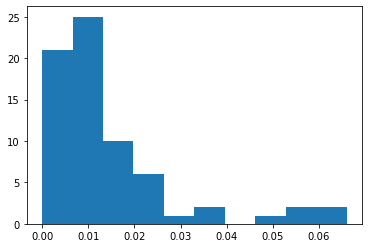

```python
plt.hist(histo_list[0])
len(histo_list)
```

## Train and Split

```python
X = np.array(histo_list)
Y = df['categories_niv1']

from sklearn.model_selection import train_test_split
x_train,x_test,y_train,y_test=train_test_split(X,Y,test_size=0.33,random_state=77)
```

## Model algorithme XGBOOST de classification

```python
mod = XGBRFClassifier()
mod.fit(x_train,y_train)
print(f"The model Xgboost is {accuracy_score(mod.predict(x_test),y_test)*100}% accurate")
```

```
[23:56:35] WARNING: ..\src\learner.cc:1061: Starting in XGBoost 1.3.0, the default evaluation metric used with the objective 'multi:softprob' was changed from 'merror' to 'mlogloss'. Explicitly set eval_metric if you'd like to restore the old behavior.
The model Xgboost is 16.714697406340058% accurate
```

## Reduction et Visualisation

```python
from sklearn.decomposition import PCA
from sklearn.manifold import TSNE
import matplotlib.pyplot as plt
import seaborn as sns
def reduction_visualisation(method):
    if(method == "PCA"):
        mod = PCA(n_components=2)
        title = "PCA decomposition"  # for the plot
    elif(method == "TSNE"):
        mod = TSNE(n_components=2)
        title = "TSNE decomposition"  # for the plot
    # Fit and transform the features
    principal_components = mod.fit_transform(X)

    # Put them into a dataframe
    df_features = pd.DataFrame(data=principal_components,
                     columns=['PC1', 'PC2'])

    # Now we have to paste each row's label and its meaning
    # Convert labels array to df
    df.replace([0,1,2,3,4,5,6],['Baby Care','Beauty and Personal Care','Computers','Home Decor & Festive Needs','Home Furnishing','Kitchen & Dining','Watches'],inplace=True)
    df_labels = df['categories_niv1']
    df_full = pd.concat([df_features, df_labels], axis=1)


    # Plot
    plt.figure(figsize=(10,10))
    sns.scatterplot(x='PC1',
                    y='PC2',
                    hue="categories_niv1",
                    data=df_full,
                    palette=["red", "pink", "royalblue", "greenyellow", "lightseagreen","black","purple"],
                    alpha=.7).set_title(title);
```

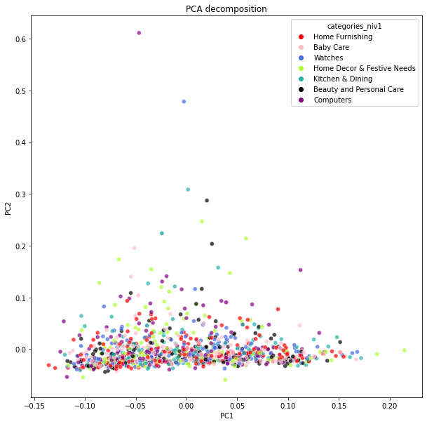

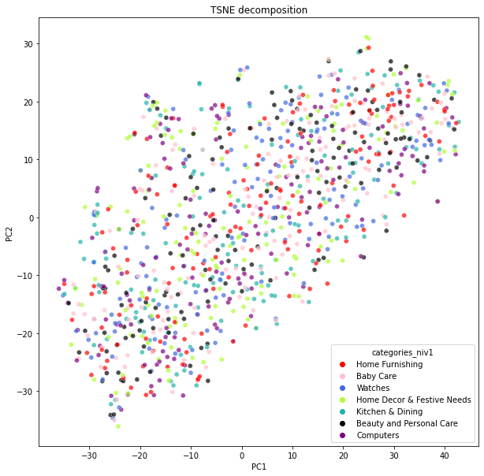

```python
reduction_visualisation('PCA')
reduction_visualisation('TSNE')
```

# Conclusion -ImageClassification = non

# 3 - Classification sur description avec NLTK

```python
nltk.download('punkt')
nltk.download('stopwords')
stemmer = PorterStemmer()
dataset = dataWCL.copy()
data = []

for i in range(dataset.shape[0]):
    description = dataset.iloc[i, 1]
    # remove non alphabatic characters
    description = re.sub('[^A-Za-z]', ' ', description)
    # make words lowercase, because Example and example will be considered as two words
    description = description.lower()
    # tokenising
    tokenized_description = wt(description)
    # remove stop words and stemming
    text_processed = []
    for word in tokenized_description:
        if word not in set(stopwords.words('english')):
            text_processed.append(stemmer.stem(word))
    description_text = " ".join(text_processed)
    data.append(description_text)

# creating the feature matrix
matrix = CountVectorizer(max_features=1000)
X = matrix.fit_transform(data).toarray()
y = dataset.iloc[:, 0]

# split train and test data
X_train, X_test, y_train, y_test = train_test_split(X, y)

# Naive Bayes
classifier = GaussianNB()
classifier.fit(X_train, y_train)

# predict class
y_pred = classifier.predict(X_test)

# Confusion matrix
cm = confusion_matrix(y_test, y_pred)
cr = classification_report(y_test, y_pred)

accuracy = accuracy_score(y_test, y_pred)
print("GaussianNB accuracy score is: ",accuracy)
```

```
GaussianNB accuracy score is:  0.8479087452471483
```

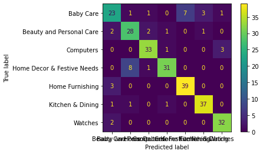

```python
#from sklearn.metrics import plot_confusion_matrix
#plot_confusion_matrix(classifier, X_test, y_test)
from sklearn.metrics import ConfusionMatrixDisplay
disp = ConfusionMatrixDisplay(confusion_matrix=cm,display_labels=classifier.classes_)
disp.plot()
plt.show()
```

```python
# Classification report
print(cr)
```

```
                            precision    recall  f1-score   support

                 Baby Care       0.74      0.64      0.69        36
  Beauty and Personal Care       0.74      0.82      0.78        34
                 Computers       0.89      0.89      0.89        37
Home Decor & Festive Needs       0.91      0.78      0.84        40
           Home Furnishing       0.85      0.93      0.89        42
          Kitchen & Dining       0.90      0.93      0.91        40
                   Watches       0.89      0.94      0.91        34

                  accuracy                           0.85       263
                 macro avg       0.85      0.85      0.84       263
              weighted avg       0.85      0.85      0.85       263
```

## Reduction et Visualisation

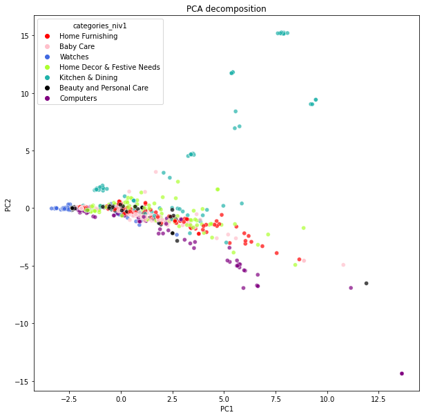

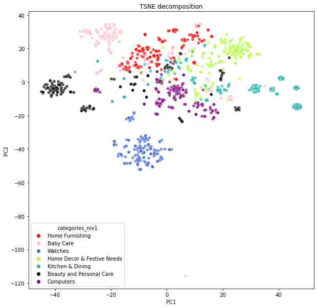

```python
reduction_visualisation('PCA')
reduction_visualisation('TSNE')
```

# Conclusion - TextClassification = oui